# Class 15 - In class exercises

Hari Subhash

Date created: 2019-04-30

## Task Set 1: Non vectorised conditional

1. Correct the code below so that it runs. The error is because I am missing an =

```r
animal <- sample(c("Birds", "Fish"), size = 1)
if(animal == "Fish"){
    print("I can swim")
} else {
    print("I can't swim")
}
```

```
[1] "I can swim"
```

2. Modify the code above to check if an animal is a “Bird” and print whether it can fly or not.

```r
if(animal == "Birds"){
    print("I can fly")
} else {
    print("I can't fly")
}
```

```
[1] "I can't fly"
```

3. Use an `if()` with `any()` to print “yes” if there are `any()` values greater than 4 in the vector x below.

```r
x <- c(3, 6, 7, 8, NA)
if(any(x > 4)){
    "yes"
}
```

```
[1] "yes"
```

Let’s break this down.

```r
x > 4
```

```
[1] FALSE  TRUE  TRUE  TRUE    NA
```

```r
any(x > 4)
```

```
[1] TRUE
```

4. Modify the code above to check if there any values that are missing in x. You can tell if an element in a vector is missing using the function `is.na()`.

```r
if(any(is.na(x))){
    "yes there are missing values"
}
```

```
[1] "yes there are missing values"
```

```r
x
```

```
[1]  3  6  7  8 NA
```

Let’s break that down.

```r
is.na(x)
```

```
[1] FALSE FALSE FALSE FALSE  TRUE
```

```r
any(is.na(x))
```

```
[1] TRUE
```

5. Modify the code you wrote for task 3 to check if there are any values greater than 8. This will likely throw an error. Can you reason why this might be giving you an error? See the documentation for `any()` to see how to address this.

```r
if(any(x > 8)){
    "There are values greater than 8"
}
```

```
Error in if (any(x > 8)) { : missing value where TRUE/FALSE needed
```

```r
x
```

```
[1]  3  6  7  8 NA
```

```r
x > 8
```

```
[1] FALSE FALSE FALSE FALSE    NA
```

```r
any(x > 8)
```

```
[1] NA
```

```r
if(NA){
    "There are values greater than 8"
}
```

```
Error in if (NA) { : missing value where TRUE/FALSE needed
```

How do we correct this? Using na.rm = T

```r
if(any(x > 8, na.rm = T)){
    "There are values greater than 8"
} else {
    "There are no values greater than 8"
}
```

```
[1] "There are no values greater than 8"
```

6. Check if `all()` the values in vector x are not missing. If yes print “yes” else print “no”.

```r
if(all(!is.na(x))) {
    "yes"
} else {
    "no"
}
```

```
[1] "no"
```

```r
x
```

```
[1]  3  6  7  8 NA
```

```r
!is.na(x)
```

```
[1]  TRUE  TRUE  TRUE  TRUE FALSE
```

```r
!F
```

```
[1] TRUE
```

```r
all(!is.na(x))
```

```
[1] FALSE
```

So the logical operators that we use commonly are

The not operator ! The AND operator & The OR operator |

## Task Set 2: Vectorized Ifs

1. Use an `if_else()` statement to create a character vector that indicates whether a given value in vector x (from previous task set) is missing. It should be marked “missing” if a value is missing and “not missing” otherwise.

```r
x
```

```
[1]  3  6  7  8 NA
```

```r
if_else(is.na(x), "missing", "not missing")
```

```
[1] "not missing" "not missing" "not missing" "not missing" "missing"
```

2. Load the gapminder and tidyverse packages

```r
library(gapminder); library(tidyverse)
```

3. Use the `if_else()` in a `mutate()` to add a new column to the gapminder data that indicates whether the year is greater than 2000.

| country | continent | year | lifeExp | pop | gdpPercap | greater2000 |
| --- | --- | --- | --- | --- | --- | --- |
| Afghanistan | Asia | 1952 | 28.80100 | 8425333 | 779.4453 | lower |
| Afghanistan | Asia | 1957 | 30.33200 | 9240934 | 820.8530 | lower |
| Afghanistan | Asia | 1962 | 31.99700 | 10267083 | 853.1007 | lower |
| Afghanistan | Asia | 1967 | 34.02000 | 11537966 | 836.1971 | lower |
| Afghanistan | Asia | 1972 | 36.08800 | 13079460 | 739.9811 | lower |
| Afghanistan | Asia | 1977 | 38.43800 | 14880372 | 786.1134 | lower |
| Afghanistan | Asia | 1982 | 39.85400 | 12881816 | 978.0114 | lower |
| Afghanistan | Asia | 1987 | 40.82200 | 13867957 | 852.3959 | lower |
| Afghanistan | Asia | 1992 | 41.67400 | 16317921 | 649.3414 | lower |
| Afghanistan | Asia | 1997 | 41.76300 | 22227415 | 635.3414 | lower |

[output cut: 990 more lines]

4. Make sure you have already loaded the tidyverse and gapminder before you start this. Complete the code below (the `group_by()` and `if_else()`). For every year I would like to mark the `incomeGroup` variable as “Higher” if it is above the median `gdpPercap` for that year (global median) and “Lower” otherwise. The subsequent plot explores the relationship between `incomeGroup` and the `lifeExp`. How would you interpret it?

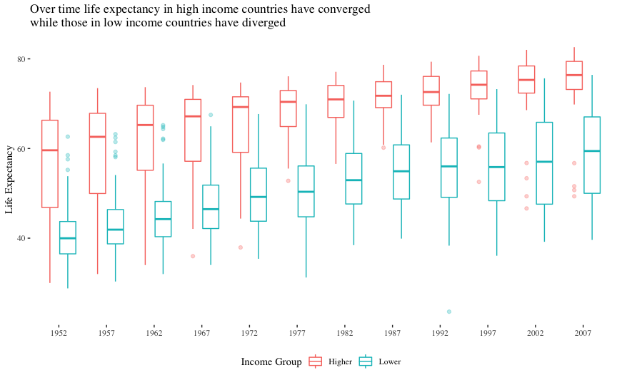

Let’s break that down a bit. Let’s output the median after grouping.

| country | year | medianValue | gdpPercap |
| --- | --- | --- | --- |
| Afghanistan | 1952 | 1968.528 | 779.4453 |
| Albania | 1952 | 1968.528 | 1601.0561 |
| Algeria | 1952 | 1968.528 | 2449.0082 |
| Angola | 1952 | 1968.528 | 3520.6103 |
| Argentina | 1952 | 1968.528 | 5911.3151 |
| Australia | 1952 | 1968.528 | 10039.5956 |
| Austria | 1952 | 1968.528 | 6137.0765 |
| Bahrain | 1952 | 1968.528 | 9867.0848 |
| Bangladesh | 1952 | 1968.528 | 684.2442 |
| Belgium | 1952 | 1968.528 | 8343.1051 |

[output cut: 990 more lines]

Let’s test this

| median(gdpPercap, na.rm = T) |
| --- |
| 1968.528 |

The next step is to establish a condition within an if else statement

| country | year | medianValue | gdpPercap | incomeGroup |
| --- | --- | --- | --- | --- |
| Afghanistan | 1952 | 1968.528 | 779.4453 | Lower |
| Albania | 1952 | 1968.528 | 1601.0561 | Lower |
| Algeria | 1952 | 1968.528 | 2449.0082 | Greater |
| Angola | 1952 | 1968.528 | 3520.6103 | Greater |
| Argentina | 1952 | 1968.528 | 5911.3151 | Greater |
| Australia | 1952 | 1968.528 | 10039.5956 | Greater |
| Austria | 1952 | 1968.528 | 6137.0765 | Greater |
| Bahrain | 1952 | 1968.528 | 9867.0848 | Greater |
| Bangladesh | 1952 | 1968.528 | 684.2442 | Lower |
| Belgium | 1952 | 1968.528 | 8343.1051 | Greater |

[output cut: 990 more lines]

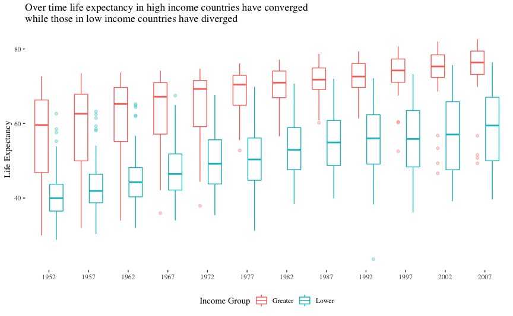

```r
gapminder %>%
    group_by(year) %>%
    mutate(medianValue = median(gdpPercap, na.rm = T)) %>%
    select(country, year, medianValue, gdpPercap, lifeExp) %>%
    mutate(incomeGroup = if_else(gdpPercap > medianValue, "Greater", "Lower")) %>%
    arrange(year, country) %>%
    ggplot(aes(x = as.factor(year), y = lifeExp, colour = incomeGroup)) +
    geom_boxplot(outlier.alpha = 0.3) +
    labs(title = str_wrap("Over time life expectancy in high income countries have converged while those in low income countries have diverged", width = 70),
         y = "Life Expectancy",
         colour = "Income Group") +
    ggthemes::theme_tufte() +
    theme(
        legend.position = "bottom",
        axis.title.x = element_blank()
    )
```

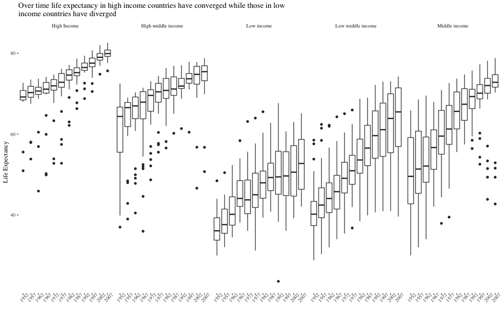